# Análisis Relacional entre los Eventos Sísmicos Ocurridos en Territorios Dominicano en el año 2014 y las Denominadas “Fallas Geológicas Mayores del País”; Análisis Geoestadístico de la Intensidad del Sismos del 03 de Julio del 2018 de República Dominicana.

Andrés María Moreta Rosario

Estudiante, Universidad Autónoma de Santo Domingo (UASD)

January 06, 2020

Abstract

El presente trabajo se presenta como practica final de la asignatura Análisis Espacial de la Maestría en Teledetección y Ciencias Geográficas, que imparte la Escuela de Ciencias Geográficas de la UASD. Para este se toma una capa de datos sísmicos del año 2014 registrado por el Centro Nacional de Sismología de la UASD, se le hace un análisis exploratorio de datos, para darnos cuenta si tienen tendencia normal y que tanto autocorrelacionados estos se encuentran . También se trata de establecer relación entre los eventos sísmicos y las fallas geológicas, consideradas como mayores por el Servicio Geológico de la República Dominicana y finalmente se hará un análisis geoestadístico de la intensidad de un evento sísmico ocurrido en la parte Este del país en el 2018.

# Introducción

Al hacer un análisis espacial es recomendable comprender los supuestos de la autocorrelación espacial, antes de hacer pruebas estadísticas o generar gráficos avanzados. Las pruebas y gráficos requieren interpretación y, al realizarlas, varios supuestos se dan por satisfechos. En tal sentido, evaluar autocorrelación requiere conocer tanto los datos como los supuestos. Los supuestos básicos que deben cumplir las observaciones son normalidad y homocedasticidad. La evaluación de normalidad es un requisito estricto al evaluar autocorrelación espacial e, igualmente, al realizar modelización espacial. Esta comprobación determinan qué tanto se acerca la distribución de los datos al modelo de la distribución normal. La mayoría de modelos estocásticos asume que las observaciones se aproximan a una media, y que se sitúan en torno a ella de forma aleatoria, siguiendo dicha distribución. Si este supuesto no se cumple, las técnicas de modelización pierden potencia o podrían arrojar relaciones erróneas. Por otra parte, la homocedasticidad aplicada al análisis espacial, asume que la media y la varianza son constantes en el espacio; es decir, se asume que no existe tendencia en los datos, y que la dispersión es invariable en las distintas localidades del conjunto de datos. No es un requisito estricto al evaluar autocorrelación, pero sí debe considerarse o atenuarse al realizar modelizaciones. La normalidad se evalúa comúnmente con la gráfica cuantilar normal, así como con pruebas estadísticas [1]. En el presente trabajo se tomaran en cuenta estos supuestos para hacer análisis reacional, modelizacion y geoestadística.

# Metodología

Se cargan los paquetes o librerías consideradas necesarias, para R poder procesar los datos y obtener resultados; se cargan las capas o datos a procesar; se realiza un análisis exploratorio de los datos y se hacen las correciones y transformaciones necesarias; se hacen algunas pruebas estadísticas a los datos sísmicos para ver si existe normalidad en estos; Se busca relación entre número de sismos y densidad de fallas por provincia y también entre la media de la magnitud de los sismos y densidad de fallas por provincia. Finalmente para la parte geoestadistica, a los distintos reportes de intensidad del evento sísmico del 2018 se le hacen los mismos análisis y pruebas estadísticas que a los sismos del 2014, se modela con varios variogramas para tomar el que mejor se ajuste a los datos, para finalizar con una interpolación Kriging.

# Resultados

## Análisis Exploratorio

Las capas de sismos estaban en distintos tipos de sistemas de coordenadas, por lo que se procedió a llevarlas todas a WGS84_19N_UTM, que es el sistema que tienen las capas de provincias y de fallasmayores, la cual es más conveniente para los análisis posteriores. La capa de sismos tenia un valor de magnitud 0, lo que es inaceptable, por lo que se procedió a filtrar la capa para no considerar este valor en el análisis.

## Estadísticos para la capa de sismos

### Prueba de Breusch-Pagan

Según los resultados de esta prueba para la capa de sismos tanto gráficamente, como con los valores de p, los datos son homocedasticos, por lo que son interpolables.

### Autocorrelación global por I de Moran

Como el p valor (p-value = 0.0001693 (peso por ventana), p-value = 0.001501(peso binario)) es inferior al nivel de significancia (comúnmente fijado en 0.05 o 0.01), se rechaza la hipótesis nula de “No hay autocorrelación espacial”.

### Autocorrelación local por magnitud

Se puedo observar en el mapa, que las provincias La Altagracia, El Seibo y La Romana, presentan alta autocorrelacion en la media de la magnitud, lo que sugiere que las magnitudes de los sismos son semejantes en estas provincias; en tanto las provincias Barahona, Bahoruco e Independencia la autcorrelacion es baja y en las demás provincias no se evidencia autocorrelacion. La provincia de Dajabon fue excluida por no tener datos.

### Autocorrelación local por cantidad de eventos

En el mapa se observa que las provincias La Altagracia, El Seibo, La Romana, San Pedro de Macoris y Monte Plata presentan alta autocorrelacion, lo que sugiere que la cantidad de sismos ocurridos son semejantes en esta provincias; en tanto las provincias Barahona, Bahoruco e Independencia, la autcorrelacion es baja y en las demás provincias no se evidencia autocorrelacion. La provincia de Dajabon fue excluida por no tener datos.

### Estadística zonal

La provincia con menor densidad de fallas geológicas mayores, resultó ser La Romana con unos 4.8 kilómetros, en tanto que la de mayor densidad fue Peravia con aproximadamente 250 kilómetros de fallas geológicas.

## Modelización

Al hacer la relación entre número de sismos y densidad de fallas por provincia, resultó un modelo homocedástico y con residuos autocorrelacionados. El modelo espacial autorregresivo obtiene un coeficiente negativo (-0.057725). En tanto que para la relación entre media de la magnitud y densidad de fallas por provincia resultó un coeficiente no significativo (-0.00062218).

## Geoestadística

### Estadísticos para la capa de intensidad del sismo del 2018

Se puedo notar que la capa tiene 38 filas, la intensidad mínima es 1, la media es 3 y la máxima es 4, el histograma de la variable original no presenta normalidad para los datos, para la variable la logarítmica el histograma presenta algo de normalidad, para la prueba de Shapiro Wilk los datos sugiere una confianza de un 93% y un coeficiente de significancia de 0,02 para la variable normal, en tanto que para la transformada la confianza baja a 89% y el valor de p es de 0.0016 lo que sugiere algo de normalidad en los datos, la prueba cuantilar sugiere una linea ondulada para ambas variables, el diagrama de caja sugiere que el 50% de los datos están al rededor de la media.

### Variogramas

Al generar varios variogramas, los datos siguieron una distribución ondulatoria, sin embargo el variograma exponencial representó mejor los resultados visuales en el mapa, por lo que se usó este ultimo para el análisis posteriores.

### Interpolación por kriging ordinario

Al realizar la Interpolación, se pudo observar en el mapa que las provincias que están mas cercanas al epicentro del evento sísmico tuvieron mayor nivel de intensidad.

# Discusión o Conclusiones

# Información de soporte

Los datos usados para este trabajo fueron:

1- Capa de eventos sísmico del 2014 del Centro Nacional de Sismología de la Universidad Autónoma de Santo Domingo.

2- Capa de fallas geológicas mayores del Servicio Geológico de la República Dominicana.

3- Capa de división política de la República Dominicana de la Oficina Nacional de Estadística de República Dominicana, como resultado del Censo Nacional 2010.

4- Reporte de intensidad del sismo del 03 de Julio del 2018 del Servio Geológico de Los Estados Unidos de Norteamérica.

# *Script* reproducible

## Evaluación de los datos reales, tanto el supuesto de normalidad como la homocedasticidad.Transformaciones y creacion de objetos.

Carguemos las librerías y la capa base y los datos a procesar

Librerías

```r
library(spdep)
library(tidyverse)
library(sf)
library(lmtest) #Necesario para la función bptest, que evalúa homocedasticidad
library(tmap)
library(RColorBrewer)
library(gstat) # Necesaria para geoestadistica
```

Capas base y Datos

```r
sismos <- st_read('data/sismos2014RD.shp')
fallasmayores <- st_read('rd_fallasdiaclasasmayores_global.gpkg')
prov <- st_read(dsn = 'data/divisionRD.gpkg', layer = 'PROVCenso2010')
sismo <- st_read('data/sismo2018.shp')
```

### Exploración de los datos

```r
sismos
```

| OBJETO | FECHA | HORA | LATITUD | LONGITUD | PROFUNDIDA | MAGNITUD | geometry |
| --- | --- | --- | --- | --- | --- | --- | --- |
| 1 | 2014-01-02 | 16:41:39 | 18.7202 | -69.6010 | 108.73 | 3.39 |  |
| 2 | 2014-01-02 | 1:26:55 | 18.9677 | -69.3110 | 90.28 | 3.37 |  |
| 3 | 2014-01-05 | 20:59:56 | 18.9668 | -70.7190 | 98.78 | 2.78 |  |
| 4 | 2014-01-05 | 19:36:10 | 18.1645 | -68.7520 | 24.79 | 2.67 |  |
| 5 | 2014-01-08 | 9:34:18 | 18.7120 | -69.1660 | 142.99 | 3.34 |  |
| 6 | 2014-01-09 | 14:57:27 | 18.7315 | -69.4240 | 85.81 | 2.97 |  |
| 7 | 2014-01-09 | 9:09:34 | 18.5348 | -70.3430 | 2.92 | 2.74 |  |
| 8 | 2014-01-12 | 0:56:12 | 18.7727 | -69.5060 | 98.02 | 2.73 |  |
| 9 | 2014-01-13 | 22:20:36 | 19.0632 | -69.9700 | 3.00 | 3.11 |  |
| 10 | 2014-01-13 | 12:37:06 | 19.0855 | -69.9640 | 10.00 | 3.00 |  |

[output cut: 430 more lines]

```r
sort(sismos$MAGNITUD, decreasing = T)
```

```
##   [1] 4.43 4.39 4.33 4.21 4.20 4.20 4.13 4.12 4.07 4.03 3.96 3.96 3.86 3.85
##  [15] 3.84 3.82 3.81 3.79 3.79 3.76 3.75 3.75 3.73 3.71 3.71 3.69 3.69 3.66
##  [29] 3.65 3.63 3.61 3.60 3.59 3.58 3.58 3.56 3.55 3.54 3.54 3.54 3.54 3.54
##  [43] 3.53 3.53 3.53 3.52 3.52 3.52 3.51 3.51 3.48 3.47 3.47 3.47 3.46 3.46
##  [57] 3.46 3.46 3.46 3.46 3.44 3.44 3.44 3.42 3.42 3.41 3.41 3.41 3.40 3.39
##  [71] 3.39 3.39 3.39 3.38 3.37 3.37 3.37 3.37 3.37 3.37 3.35 3.35 3.35 3.35
##  [85] 3.35 3.34 3.34 3.34 3.34 3.33 3.33 3.33 3.33 3.33 3.33 3.33 3.31 3.31
##  [99] 3.31 3.31 3.31 3.30 3.30 3.29 3.29 3.29 3.28 3.28 3.28 3.28 3.27 3.27
## [113] 3.27 3.27 3.27 3.27 3.27 3.26 3.26 3.25 3.25 3.25 3.24 3.24 3.24 3.23
## [127] 3.23 3.23 3.23 3.22 3.22 3.22 3.22 3.22 3.21 3.21 3.21 3.20 3.20 3.20
## [141] 3.20 3.19 3.19 3.19 3.19 3.18 3.18 3.18 3.18 3.18 3.18 3.18 3.18 3.17
## [155] 3.17 3.17 3.17 3.17 3.17 3.17 3.16 3.16 3.16 3.16 3.16 3.16 3.16 3.16
## [169] 3.16 3.15 3.15 3.15 3.15 3.15 3.15 3.15 3.14 3.14 3.14 3.13 3.13 3.13
## [183] 3.13 3.12 3.12 3.12 3.11 3.11 3.11 3.11 3.11 3.11 3.10 3.10 3.10 3.10
## [197] 3.09 3.09 3.09 3.09 3.09 3.09 3.09 3.08 3.08 3.08 3.08 3.08 3.08 3.08
```

[output cut: 17 more lines]

```r
sismos <- sismos %>% filter(MAGNITUD>0)
sismos
```

|  | OBJETO | FECHA | HORA | LATITUD | LONGITUD | PROFUNDIDA | MAGNITUD | geometry |
| --- | --- | --- | --- | --- | --- | --- | --- | --- |
| 1 | 1 | 2014-01-02 | 16:41:39 | 18.7202 | -69.6010 | 108.73 | 3.39 |  |
| 2 | 2 | 2014-01-02 | 1:26:55 | 18.9677 | -69.3110 | 90.28 | 3.37 |  |
| 3 | 3 | 2014-01-05 | 20:59:56 | 18.9668 | -70.7190 | 98.78 | 2.78 |  |
| 4 | 4 | 2014-01-05 | 19:36:10 | 18.1645 | -68.7520 | 24.79 | 2.67 |  |
| 5 | 5 | 2014-01-08 | 9:34:18 | 18.7120 | -69.1660 | 142.99 | 3.34 |  |
| 6 | 6 | 2014-01-09 | 14:57:27 | 18.7315 | -69.4240 | 85.81 | 2.97 |  |
| 7 | 7 | 2014-01-09 | 9:09:34 | 18.5348 | -70.3430 | 2.92 | 2.74 |  |
| 8 | 8 | 2014-01-12 | 0:56:12 | 18.7727 | -69.5060 | 98.02 | 2.73 |  |
| 9 | 9 | 2014-01-13 | 22:20:36 | 19.0632 | -69.9700 | 3.00 | 3.11 |  |
| 10 | 10 | 2014-01-13 | 12:37:06 | 19.0855 | -69.9640 | 10.00 | 3.00 |  |

[output cut: 429 more lines]

```r
fallasmayores
```

| PROV | MUN | RDFRA250_ | RDFRA250_I | ID | COD_TEMA | COD_FI | COD_CAPA | TABLA | ENLACE | TIPOGLOBAL | geom |
| --- | --- | --- | --- | --- | --- | --- | --- | --- | --- | --- | --- |
| NA | NA | 1 | 302 | 302 | NA | NA | NA | NA | 0 | falla indiferenciado |  |
| NA | NA | 2 | 302 | 302 | NA | NA | NA | NA | 1 | falla indiferenciado |  |
| NA | NA | 3 | 302 | 302 | NA | NA | NA | NA | 2 | falla indiferenciado |  |
| NA | NA | 4 | 302 | 302 | NA | NA | NA | NA | 3 | falla indiferenciado |  |
| NA | NA | 5 | 301 | 301 | NA | NA | NA | NA | 4 | falla indiferenciado |  |
| NA | NA | 6 | 306 | 306 | NA | NA | NA | NA | 5 | falla indiferenciado |  |
| NA | NA | 7 | 301 | 301 | NA | NA | NA | NA | 6 | falla indiferenciado |  |
| NA | NA | 8 | 301 | 301 | NA | NA | NA | NA | 7 | falla indiferenciado |  |
| NA | NA | 9 | 306 | 306 | NA | NA | NA | NA | 8 | falla indiferenciado |  |
| NA | NA | 10 | 301 | 301 | NA | NA | NA | NA | 9 | falla indiferenciado |  |

[output cut: 925 more lines]

```r
prov
```

| PROV | REG | TOPONIMIA | ENLACE | geom |
| --- | --- | --- | --- | --- |
| 01 | 10 | DISTRITO NACIONAL | 1001 |  |
| 02 | 05 | AZUA | 0502 |  |
| 03 | 06 | BAORUCO | 0603 |  |
| 04 | 06 | BARAHONA | 0604 |  |
| 05 | 04 | DAJABÓN | 0405 |  |
| 06 | 03 | DUARTE | 0306 |  |
| 07 | 07 | ELÍAS PIÑA | 0707 |  |
| 08 | 08 | EL SEIBO | 0808 |  |
| 09 | 01 | ESPAILLAT | 0109 |  |
| 10 | 06 | INDEPENDENCIA | 0610 |  |

[output cut: 22 more lines]

```r
sismo
```

| F__Columns | CDI | No__of_res | Hypocentra | Latitude | Longitude | Suspect_ | City | geometry |
| --- | --- | --- | --- | --- | --- | --- | --- | --- |
| Pimentel::Duarte::Dominican Republic | 3.3 | 1 | 99 | 19.18 | -70.11 | 0 | Pimentel |  |
| San Francisco de Macorís::Duarte::Dominican Republic | 2.0 | 1 | 111 | 19.30 | -70.25 | 0 | San Francisco de Macorís |  |
| El Llano::Elías Piña::Dominican Republic | 2.6 | 3 | 227 | 18.82 | -71.63 | 0 | El Llano |  |
| Jamao al Norte::Espaillat::Dominican Republic | 2.0 | 1 | 140 | 19.65 | -70.45 | 0 | Jamao al Norte |  |
| Moca::Espaillat::Dominican Republic | 2.0 | 1 | 133 | 19.40 | -70.53 | 0 | Moca |  |
| Hato Mayor::Hato Mayor::Dominican Republic | 4.2 | 3 | 96 | 18.77 | -69.26 | 0 | Hato Mayor |  |
| Higüey::La Altagracia::Dominican Republic | 3.1 | 1 | 135 | 18.62 | -68.71 | 0 | Higüey |  |
| Otra Banda::La Altagracia::Dominican Republic | 3.0 | 4 | 137 | 18.65 | -68.67 | 0 | Otra Banda |  |
| La Romana::La Romana::Dominican Republic | 2.0 | 3 | 126 | 18.43 | -68.97 | 0 | La Romana |  |
| La Vega::La Vega::Dominican Republic | 3.4 | 1 | 128 | 19.22 | -70.53 | 0 | La Vega |  |

[output cut: 28 more lines]

### Transformacion de sistemas de coordenadas a las capas

```r
crswgs84utm <- 32619
sismoutm <- sismo %>% st_transform(crs = crswgs84utm)
sismosutm <- sismos %>% st_transform(crs = crswgs84utm)
```

### Creacion de objetos sp

Convenientes para manipular, importar y exportar datos espaciales

```r
prov.sp <- as_Spatial(prov)
sismo.sp <- as_Spatial(sismoutm)
sismos.sp <- as_Spatial(sismosutm)
```

### Superposicion de capas

Verificación de que las capas se superponen una a otras

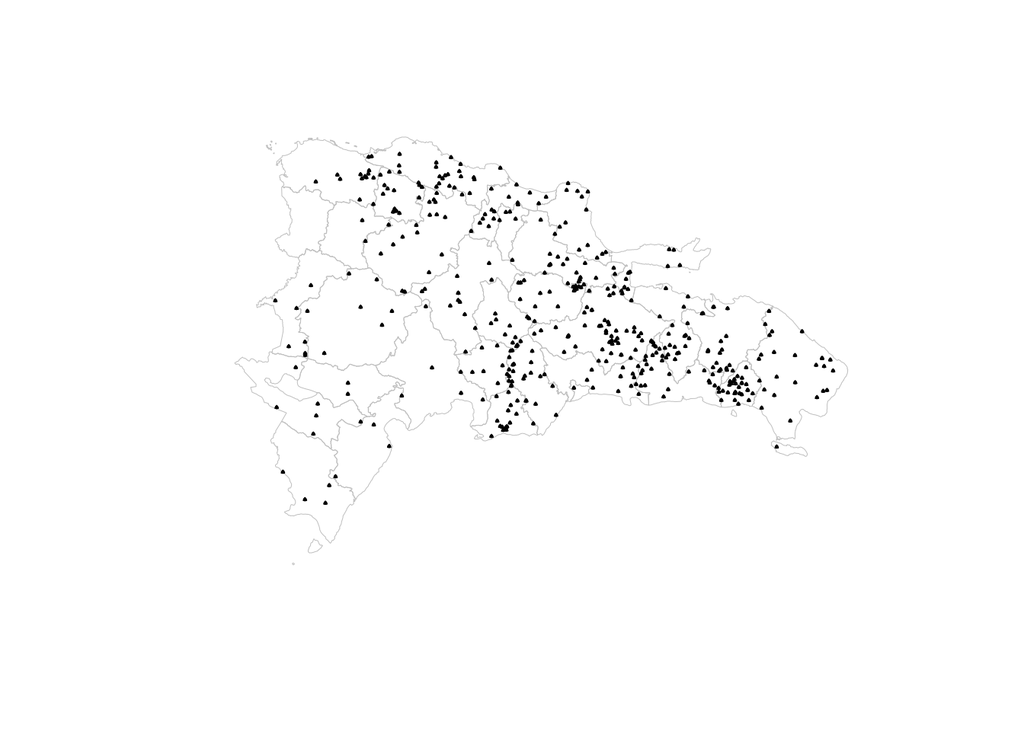

```r
plot(prov.sp, border="grey", lwd=0.5)
plot(sismos.sp, pch = 1, cex = 0.2, add=T)
plot(sismos.sp, pch = 2, cex = 0.2, add=T)
```

## Estadísticos básicos para la capa de sismos

```r
nrow(sismos)
```

```
## [1] 439
```

```r
summary(sismos$MAGNITUD)
```

```
##    Min. 1st Qu.  Median    Mean 3rd Qu.    Max.
##   1.670   2.820   3.070   3.053   3.275   4.430
```

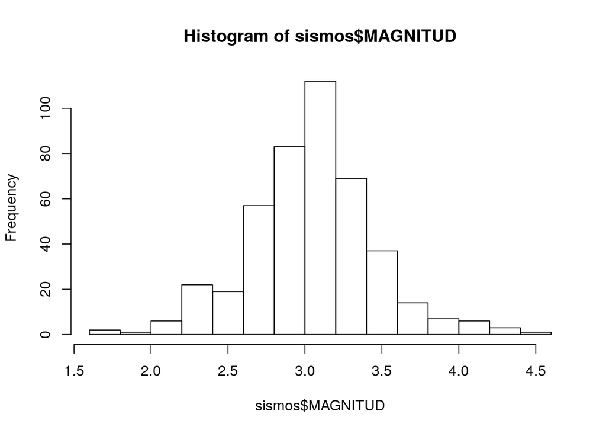

```r
hist(sismos$MAGNITUD)
```

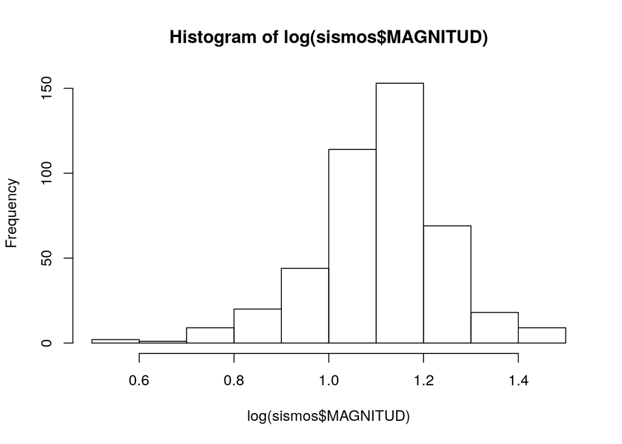

```r
hist(log(sismos$MAGNITUD))
```

```r
shapiro.test(sismos$MAGNITUD)
```

```
##
##  Shapiro-Wilk normality test
##
## data:  sismos$MAGNITUD
## W = 0.98381, p-value = 8.151e-05
```

```r
shapiro.test(log(sismos$MAGNITUD))
```

```
##
##  Shapiro-Wilk normality test
##
## data:  log(sismos$MAGNITUD)
## W = 0.97136, p-value = 1.419e-07
```

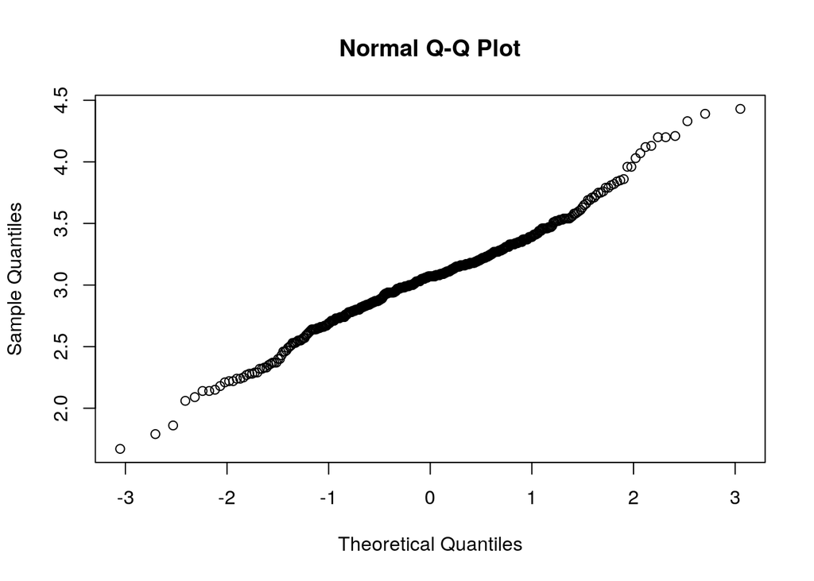

```r
qqnorm(sismos$MAGNITUD)
```

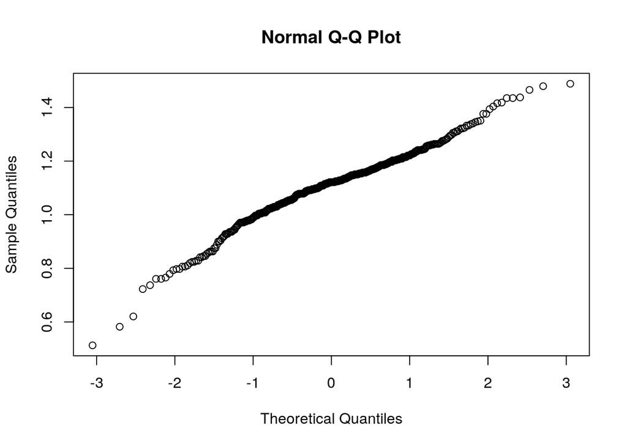

```r
qqnorm(log(sismos$MAGNITUD))
```

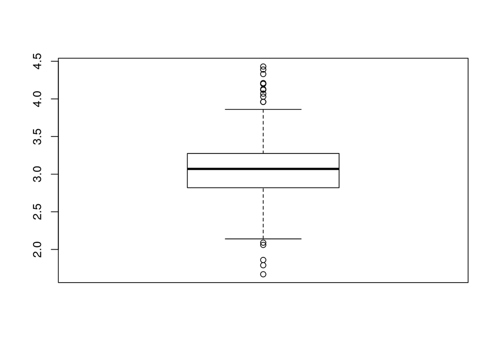

```r
boxplot(sismos$MAGNITUD)
```

### Generacion de variograma para la capa de sismos

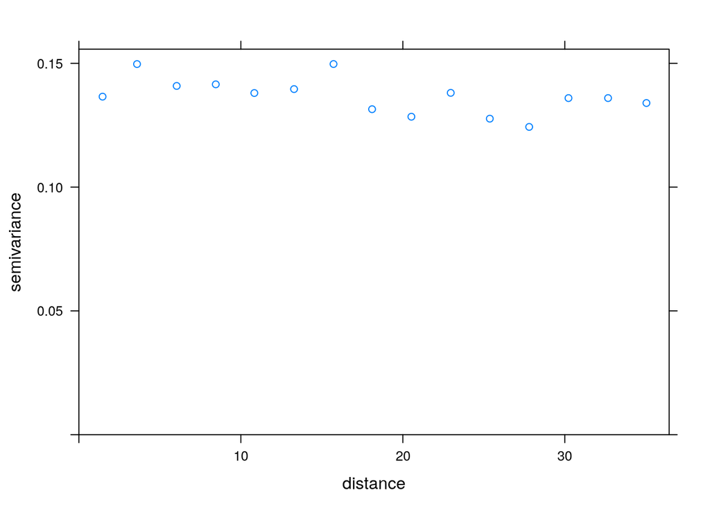

```r
vsismos <- variogram(MAGNITUD~1, sismos)
plot(vsismos)
```

### Despliege de estadisticos de la magnitud de los sismos y graficado de estos en la capa de provincias

```r
sismosprovdf <- prov %>%
  st_intersection(sismosutm) %>%
  st_drop_geometry() %>%
  select(ENLACE, MAGNITUD) %>%
  group_by(ENLACE) %>%
  summarise(med=mean(MAGNITUD, na.rm=T), var=var(MAGNITUD, na.rm = T),
            min=min(MAGNITUD, na.rm=T), max=max(MAGNITUD, na.rm = T), N=n())
sismosprovsf <- prov %>% inner_join(sismosprovdf, by = 'ENLACE')
sismosprovsf
```

| PROV | REG | TOPONIMIA | ENLACE | med | var | min | max | N | geom |
| --- | --- | --- | --- | --- | --- | --- | --- | --- | --- |
| 01 | 10 | DISTRITO NACIONAL | 1001 | 2.730000 | NA | 2.73 | 2.73 | 1 |  |
| 02 | 05 | AZUA | 0502 | 2.948000 | 0.06582000 | 2.61 | 3.23 | 5 |  |
| 03 | 06 | BAORUCO | 0603 | 2.450000 | 0.25920000 | 2.09 | 2.81 | 2 |  |
| 04 | 06 | BARAHONA | 0604 | 2.743333 | 0.24103333 | 2.18 | 3.08 | 3 |  |
| 06 | 03 | DUARTE | 0306 | 2.841111 | 0.24341046 | 1.67 | 3.37 | 18 |  |
| 07 | 07 | ELÍAS PIÑA | 0707 | 2.647143 | 0.11625714 | 2.32 | 3.18 | 7 |  |
| 08 | 08 | EL SEIBO | 0808 | 3.275789 | 0.19077018 | 2.55 | 4.13 | 19 |  |
| 09 | 01 | ESPAILLAT | 0109 | 3.200667 | 0.15279238 | 2.73 | 4.43 | 15 |  |
| 10 | 06 | INDEPENDENCIA | 0610 | 2.740000 | 0.26712000 | 2.24 | 3.53 | 6 |  |
| 11 | 08 | LA ALTAGRACIA | 0811 | 3.461667 | 0.10930145 | 2.82 | 4.39 | 24 |  |

[output cut: 21 more lines]

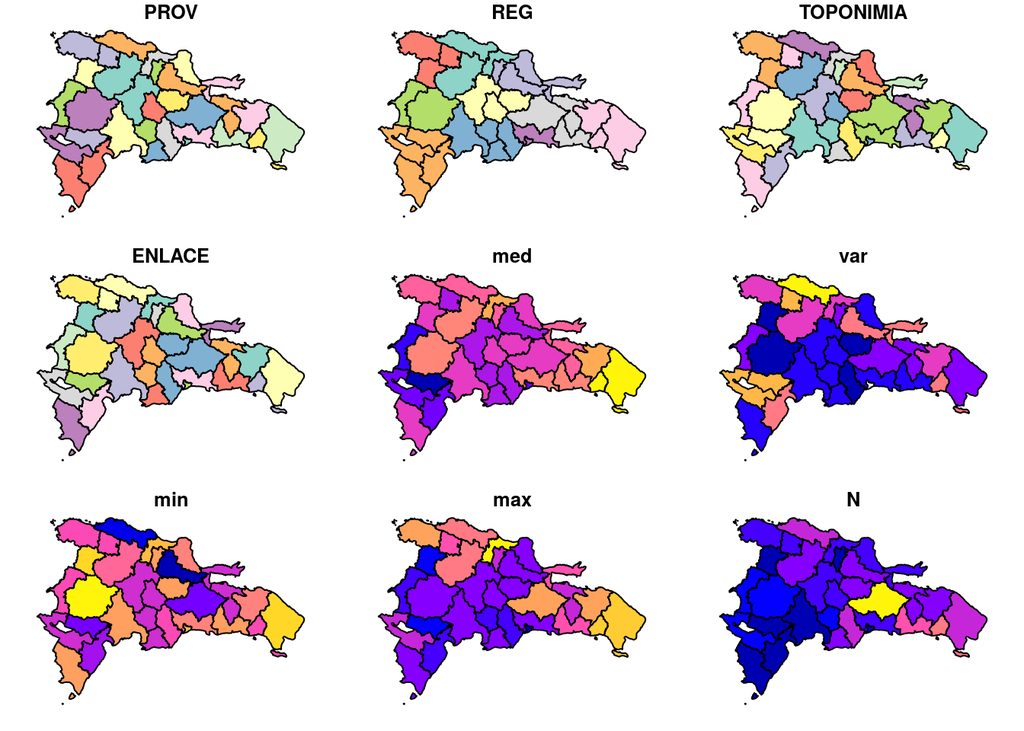

```r
plot(sismosprovsf)
```

## Vecindad

```r
rownames(sismosprovsf) <- sismosprovsf$TOPONIMIA
nb <- poly2nb(sismosprovsf)
summary(nb)
```

```
## Neighbour list object:
## Number of regions: 31
## Number of nonzero links: 138
## Percentage nonzero weights: 14.36004
## Average number of links: 4.451613
## Link number distribution:
##
## 1 2 3 4 5 6 7 8 9
## 1 2 6 9 6 3 2 1 1
## 1 least connected region:
## DISTRITO NACIONAL with 1 link
## 1 most connected region:
## LA VEGA with 9 links
```

```r
is.symmetric.nb(nb)
```

```
## [1] TRUE
```

```r
card(nb)
```

```
##  [1] 1 6 4 4 7 3 4 6 5 2 3 9 3 3 2 3 4 3 4 5 7 5 4 6 5 4 5 8 4 5 4
```

### Ponderadores espaciales (Pesos), estandarizado por filas (w.W) y binario (w.B)

```r
wW <- nb2listw(nb)
summary(wW)
```

```
## Characteristics of weights list object:
## Neighbour list object:
## Number of regions: 31
## Number of nonzero links: 138
## Percentage nonzero weights: 14.36004
## Average number of links: 4.451613
## Link number distribution:
##
## 1 2 3 4 5 6 7 8 9
## 1 2 6 9 6 3 2 1 1
## 1 least connected region:
## DISTRITO NACIONAL with 1 link
## 1 most connected region:
## LA VEGA with 9 links
##
## Weights style: W
## Weights constants summary:
##    n  nn S0       S1       S2
## W 31 961 31 15.53669 128.9319
```

```r
wB <- nb2listw(nb, style = 'B')
summary(wB)
```

```
## Characteristics of weights list object:
## Neighbour list object:
## Number of regions: 31
## Number of nonzero links: 138
## Percentage nonzero weights: 14.36004
## Average number of links: 4.451613
## Link number distribution:
##
## 1 2 3 4 5 6 7 8 9
## 1 2 6 9 6 3 2 1 1
## 1 least connected region:
## DISTRITO NACIONAL with 1 link
## 1 most connected region:
## LA VEGA with 9 links
##
## Weights style: B
## Weights constants summary:
##    n  nn  S0  S1   S2
## B 31 961 138 276 2832
```

### Prueba de Breusch-Pagan

Se preparan los datos y se añaden columnas x,y

```r
coordsxy <- sismosprovsf %>%
  st_centroid() %>%
  mutate(x=unlist(map(geom,1)),
         y=unlist(map(geom,2))) %>%
  st_drop_geometry() %>%
  select(ENLACE, x, y)
coordsxy
```

|  | ENLACE | x | y |
| --- | --- | --- | --- |
| 1 | 1001 | 400578.3 | 2044093 |
| 2 | 0502 | 306538.2 | 2055500 |
| 3 | 0603 | 253648.9 | 2048423 |
| 4 | 0604 | 265654.1 | 2010069 |
| 5 | 0306 | 386306.5 | 2129851 |
| 6 | 0707 | 225124.2 | 2102815 |
| 7 | 0808 | 495201.2 | 2080870 |
| 8 | 0109 | 353886.4 | 2160683 |
| 9 | 0610 | 223355.0 | 2038578 |
| 10 | 0811 | 536305.4 | 2054312 |

[output cut: 21 more lines]

```r
sismosprovsf <- sismosprovsf %>%
  inner_join(coordsxy)
```

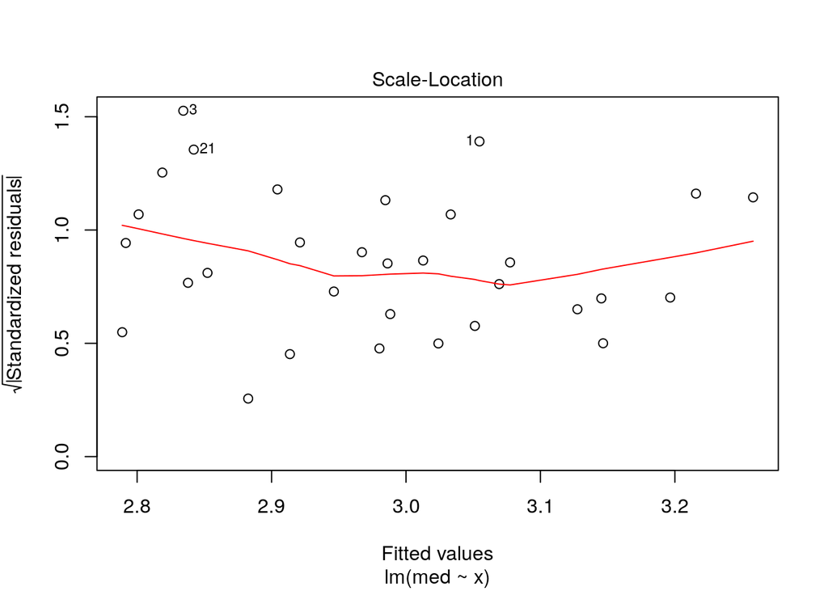

```r
sismosprovsf %>% lm(med~ x, .) %>% plot(3)
```

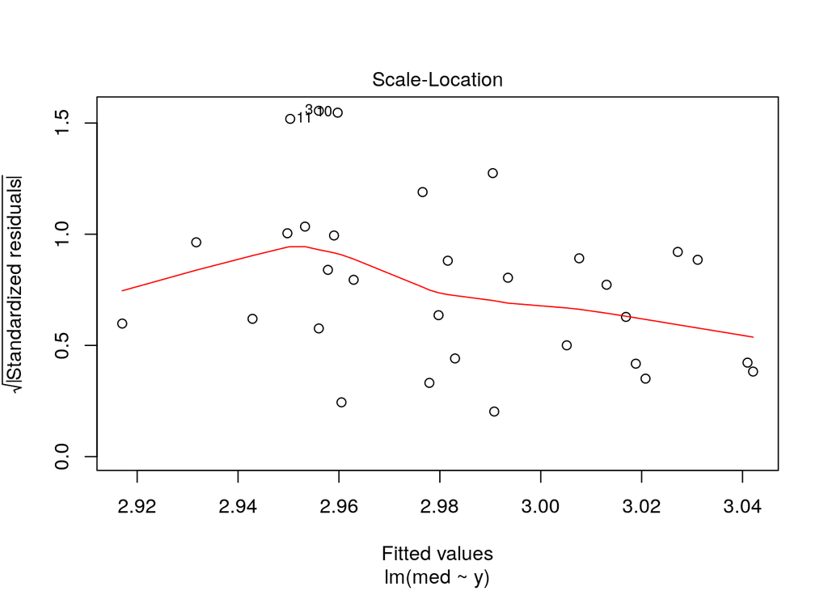

```r
sismosprovsf %>% lm(med~ y, .) %>% plot(3)
```

```r
sismosprovsf %>% lm(med~ x, .) %>% bptest()
```

```
##
##  studentized Breusch-Pagan test
##
## data:  .
## BP = 1.2218, df = 1, p-value = 0.269
```

```r
sismosprovsf %>% lm(med~ y, .) %>% bptest()
```

```
##
##  studentized Breusch-Pagan test
##
## data:  .
## BP = 2.9431, df = 1, p-value = 0.08624
```

### Autocorrelación global por I de Moran

```r
(gmoranw <- moran.test(x = sismosprovsf$med, listw = wW, na.action = na.omit))
```

```
##
##  Moran I test under randomisation
##
## data:  sismosprovsf$med
## weights: wW
##
## Moran I statistic standard deviate = 3.5838, p-value = 0.0001693
## alternative hypothesis: greater
## sample estimates:
## Moran I statistic       Expectation          Variance
##        0.38347105       -0.03333333        0.01352607
```

```r
(gmoranb <- moran.test(x = sismosprovsf$med, listw = wB, na.action = na.omit))
```

```
##
##  Moran I test under randomisation
##
## data:  sismosprovsf$med
## weights: wB
##
## Moran I statistic standard deviate = 2.9675, p-value = 0.001501
## alternative hypothesis: greater
## sample estimates:
## Moran I statistic       Expectation          Variance
##        0.28414338       -0.03333333        0.01144585
```

### Autocorrelación local por magnitud

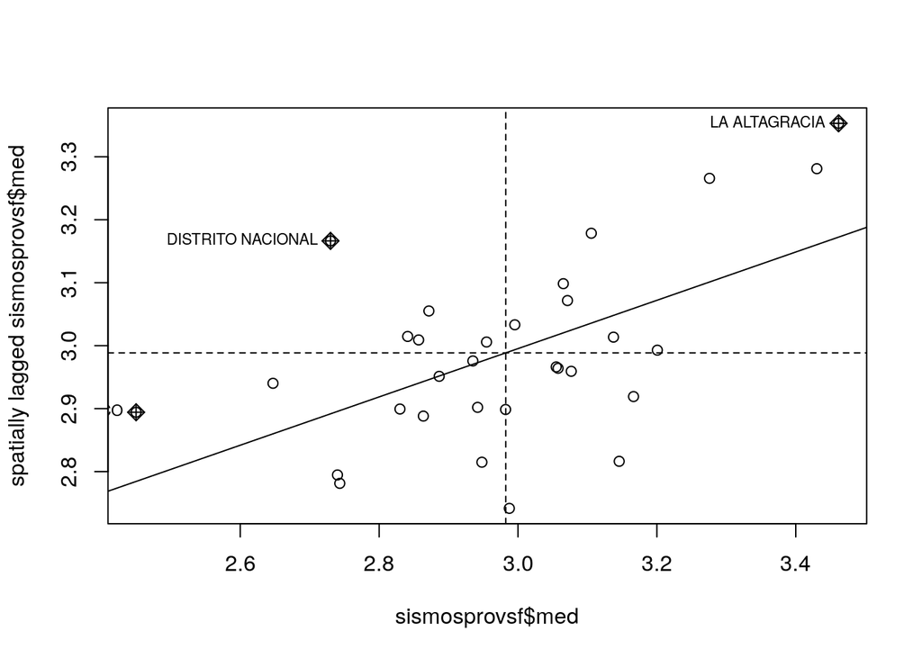

```r
moran.plot(x = sismosprovsf$med, listw = wW)
```

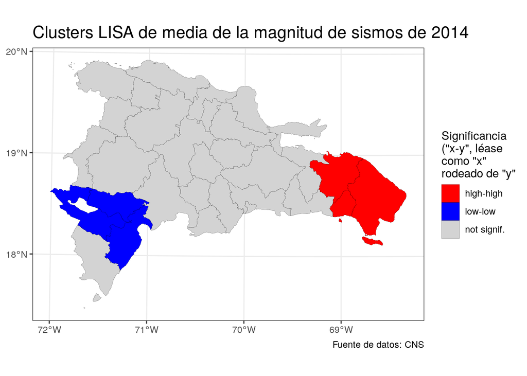

```
##
## $objeto
## Simple feature collection with 31 features and 14 fields
## geometry type:  MULTIPOLYGON
## dimension:      XY
## bbox:           xmin: 182215.8 ymin: 1933532 xmax: 571365.3 ymax: 2205216
## epsg (SRID):    32619
## proj4string:    +proj=utm +zone=19 +datum=WGS84 +units=m +no_defs
## First 10 features:
##    PROV REG         TOPONIMIA ENLACE      med       var  min  max  N
## 1    01  10 DISTRITO NACIONAL   1001 2.730000        NA 2.73 2.73  1
## 2    02  05              AZUA   0502 2.948000 0.0658200 2.61 3.23  5
## 3    03  06           BAORUCO   0603 2.450000 0.2592000 2.09 2.81  2
## 4    04  06          BARAHONA   0604 2.743333 0.2410333 2.18 3.08  3
## 5    06  03            DUARTE   0306 2.841111 0.2434105 1.67 3.37 18
```

[output cut: 27 more lines]

```r
source('lisaclusters.R')
lisamap(objesp =  sismosprovsf,
        var = 'med',
        pesos = wW,
        tituloleyenda = 'Significancia\n("x-y", léase\ncomo "x"\nrodeado de "y"',
        leyenda = T,
        anchuratitulo = 1000,
        tamanotitulo = 16,
        fuentedatos = 'CNS',
        titulomapa = paste0('Clusters LISA de media de la magnitud de sismos de 2014'))
```

### Autocorrelación local por cantidad de eventos

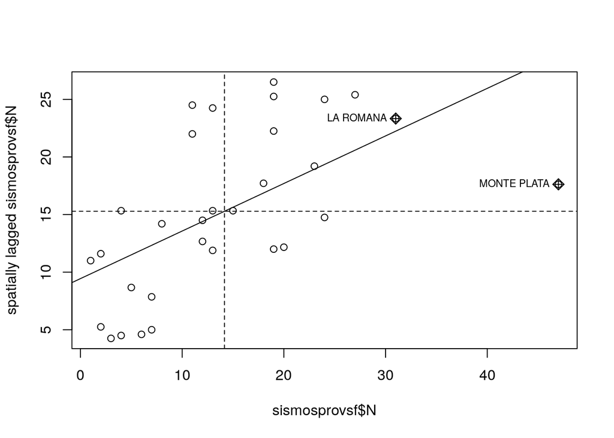

```r
moran.plot(x = sismosprovsf$N, listw = wW)
```

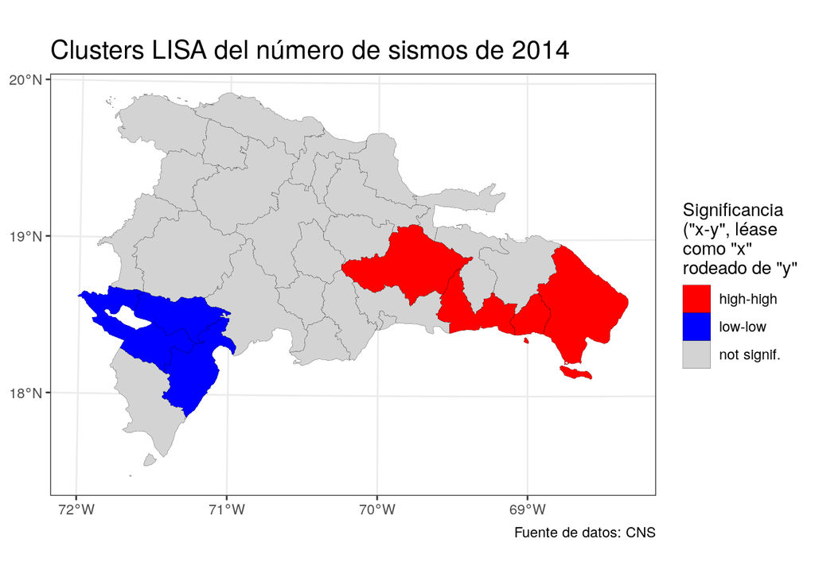

```
##
## $objeto
## Simple feature collection with 31 features and 14 fields
## geometry type:  MULTIPOLYGON
## dimension:      XY
## bbox:           xmin: 182215.8 ymin: 1933532 xmax: 571365.3 ymax: 2205216
## epsg (SRID):    32619
## proj4string:    +proj=utm +zone=19 +datum=WGS84 +units=m +no_defs
## First 10 features:
##    PROV REG         TOPONIMIA ENLACE      med       var  min  max  N
## 1    01  10 DISTRITO NACIONAL   1001 2.730000        NA 2.73 2.73  1
## 2    02  05              AZUA   0502 2.948000 0.0658200 2.61 3.23  5
## 3    03  06           BAORUCO   0603 2.450000 0.2592000 2.09 2.81  2
## 4    04  06          BARAHONA   0604 2.743333 0.2410333 2.18 3.08  3
## 5    06  03            DUARTE   0306 2.841111 0.2434105 1.67 3.37 18
```

[output cut: 27 more lines]

```r
lisamap(objesp =  sismosprovsf,
        var = 'N',
        pesos = wW,
        tituloleyenda = 'Significancia\n("x-y", léase\ncomo "x"\nrodeado de "y"',
        leyenda = T,
        anchuratitulo = 1000,
        tamanotitulo = 16,
        fuentedatos = 'CNS',
        titulomapa = paste0('Clusters LISA del número de sismos de 2014'))
```

## Estadística zonal

```r
devtools::source_url('https://raw.githubusercontent.com/geofis/zonal-stats-sf/master/zonal-stats-sf.R')
```

```
## SHA-1 hash of file is 39a34cd2f8ac93e5f6d576a9da514ec44950c4db
```

```r
ezfallasprov <- zstatsf(zones = prov, values = fallasmayores, grpx = 'TOPONIMIA', grpy = 'TIPOGLOBAL')
```

Uniendo con el `sf` central:

```r
sismosprovsf2 <- sismosprovsf %>%
  right_join(ezfallasprov %>% st_drop_geometry %>% rename(km_falla_por_km2 = `falla indiferenciado`), by = 'TOPONIMIA')
```

Densidad de fallas geológicas por provincias

```r
sismosprovsf2 %>% st_drop_geometry() %>%
  dplyr::select(TOPONIMIA,km_falla_por_km2)
```

|  | TOPONIMIA | km_falla_por_km2 |
| --- | --- | --- |
| 1 | AZUA | 149.705774 |
| 2 | BAORUCO | 90.429174 |
| 3 | BARAHONA | 148.071735 |
| 4 | DAJABÓN | 33.435485 |
| 5 | DUARTE | 156.167525 |
| 6 | EL SEIBO | 68.751545 |
| 7 | ELÍAS PIÑA | 103.615453 |
| 8 | ESPAILLAT | 182.850996 |
| 9 | HATO MAYOR | 47.748713 |
| 10 | HERMANAS MIRABAL | 96.735143 |

[output cut: 21 more lines]

## Modelización

### Relación entre número de sismos y densidad de fallas por provincia

```r
modlin1 <- sismosprovsf2 %>% select(km_falla_por_km2, N) %>%
  st_drop_geometry() %>% lm(N ~ km_falla_por_km2, ., na.action = na.aggregate)
modlin1 %>% summary
```

```
##
## Call:
## lm(formula = N ~ km_falla_por_km2, data = ., na.action = na.aggregate)
##
## Residuals:
##     Min      1Q  Median      3Q     Max
## -16.763  -5.944  -1.399   5.640  28.975
##
## Coefficients:
##                  Estimate Std. Error t value Pr(>|t|)
## (Intercept)      20.20460    2.96752   6.809 1.78e-07 ***
## km_falla_por_km2 -0.05730    0.02521  -2.273   0.0306 *
## ---
## Signif. codes:  0 '***' 0.001 '**' 0.01 '*' 0.05 '.' 0.1 ' ' 1
##
## Residual standard error: 9.193 on 29 degrees of freedom
## Multiple R-squared:  0.1512, Adjusted R-squared:  0.1219
## F-statistic: 5.166 on 1 and 29 DF,  p-value: 0.03062
```

```r
modlin1 %>% bptest # Modelo homocedástico
```

```
##
##  studentized Breusch-Pagan test
##
## data:  .
## BP = 1.1414, df = 1, p-value = 0.2854
```

```r
moran.test(x = as.vector(modlin1$residuals), listw = wW) # Residuos autocorrelacionados
```

```
##
##  Moran I test under randomisation
##
## data:  as.vector(modlin1$residuals)
## weights: wW
##
## Moran I statistic standard deviate = 2.1956, p-value = 0.01406
## alternative hypothesis: greater
## sample estimates:
## Moran I statistic       Expectation          Variance
##        0.21589701       -0.03333333        0.01288530
```

### Relación entre media de la magnitud y densidad de fallas por provincia

```r
modlin2 <- sismosprovsf2 %>% select(km_falla_por_km2, med) %>%
  st_drop_geometry() %>% lm(med ~ km_falla_por_km2, ., na.action = na.aggregate)
modlin2 %>% summary
```

```
##
## Call:
## lm(formula = med ~ km_falla_por_km2, data = ., na.action = na.aggregate)
##
## Residuals:
##      Min       1Q   Median       3Q      Max
## -0.54519 -0.11924 -0.01199  0.11035  0.46832
##
## Coefficients:
##                    Estimate Std. Error t value Pr(>|t|)
## (Intercept)       3.0488902  0.0673322  45.281   <2e-16 ***
## km_falla_por_km2 -0.0005938  0.0005720  -1.038    0.308
## ---
## Signif. codes:  0 '***' 0.001 '**' 0.01 '*' 0.05 '.' 0.1 ' ' 1
##
## Residual standard error: 0.2086 on 29 degrees of freedom
## Multiple R-squared:  0.03583,    Adjusted R-squared:  0.002581
## F-statistic: 1.078 on 1 and 29 DF,  p-value: 0.3078
```

### Espacial autorregresivo

```r
sar1 <- sismosprovsf2 %>% select(N, km_falla_por_km2) %>%
  st_drop_geometry() %>%
  spautolm(
    formula = N ~ km_falla_por_km2,
    data = .,
    listw = wW)
summary(sar1)
```

```
##
## Call: spautolm(formula = N ~ km_falla_por_km2, data = ., listw = wW)
##
## Residuals:
```

```
##      Min       1Q   Median       3Q      Max
## -16.4211  -4.6963  -2.0406   3.8499  26.0328
##
## Coefficients:
##                   Estimate Std. Error z value  Pr(>|z|)
## (Intercept)      20.088676   3.326375  6.0392 1.549e-09
## km_falla_por_km2 -0.057725   0.020326 -2.8399  0.004512
##
## Lambda: 0.4249 LR test value: 2.798 p-value: 0.094384
## Numerical Hessian standard error of lambda: 0.23129
```

```
##
## Log likelihood: -107.1235
## ML residual variance (sigma squared): 70.48, (sigma: 8.3952)
## Number of observations: 30
## Number of parameters estimated: 4
```

```
## AIC: 222.25
```

```r
sar2 <- sismosprovsf2 %>% select(med, km_falla_por_km2) %>%
  st_drop_geometry() %>%
  spautolm(
    formula = med ~ km_falla_por_km2,
    data = .,
    listw = wW)
summary(sar2)
```

```
##
## Call: spautolm(formula = med ~ km_falla_por_km2, data = ., listw = wW)
##
## Residuals:
```

```
##        Min         1Q     Median         3Q        Max
## -0.5411440 -0.1059011 -0.0091208  0.1064554  0.4597772
##
## Coefficients:
##                     Estimate  Std. Error z value Pr(>|z|)
## (Intercept)       3.05398366  0.06800907 44.9055   <2e-16
## km_falla_por_km2 -0.00062218  0.00058665 -1.0606   0.2889
##
## Lambda: -0.089904 LR test value: 0.12521 p-value: 0.72345
## Numerical Hessian standard error of lambda: 0.25441
```

```
##
## Log likelihood: 5.044697
## ML residual variance (sigma squared): 0.04175, (sigma: 0.20433)
## Number of observations: 30
## Number of parameters estimated: 4
```

```
## AIC: -2.0894
```

## Geoestadística

En esta parte usaremos los reportes de intensidad de un evento sismico ocurrido el 03 de Julio del 2018, a las 05:31 am hora local, en las coordenadas 18.9965N y 69.6349W. Con esto se persigue la obtención de valores en lugares no reportados.